# Quiz 2

Ryan Richardson

19/11/2020

## R Markdown

```r
d <- read.dta('wcgs.dta')
summary(d)
```

```
##       age            arcus        behpat         bmi        chd69
##  Min.   :39.00   Min.   :0.0000   A1: 264   Min.   :11.19   No :2897
##  1st Qu.:42.00   1st Qu.:0.0000   A2:1325   1st Qu.:22.96   Yes: 257
##  Median :45.00   Median :0.0000   B3:1216   Median :24.39
##  Mean   :46.28   Mean   :0.2985   B4: 349   Mean   :24.52
##  3rd Qu.:50.00   3rd Qu.:1.0000             3rd Qu.:25.84
##  Max.   :59.00   Max.   :1.0000             Max.   :38.95
##                  NA's   :2
##       chol            dbp            dibpat         height            id
##  Min.   :103.0   Min.   : 58.00   Type B:1565   Min.   :60.00   Min.   : 2001
##  1st Qu.:197.2   1st Qu.: 76.00   Type A:1589   1st Qu.:68.00   1st Qu.: 3741
##  Median :223.0   Median : 80.00                 Median :70.00   Median :11406
##  Mean   :226.4   Mean   : 82.02                 Mean   :69.78   Mean   :10478
##  3rd Qu.:253.0   3rd Qu.: 86.00                 3rd Qu.:72.00   3rd Qu.:13115
##  Max.   :645.0   Max.   :150.00                 Max.   :78.00   Max.   :22101
##  NA's   :12
##      lnsbp           lnwght          ncigs           sbp        smoke
##  Min.   :4.585   Min.   :4.357   Min.   : 0.0   Min.   : 98.0   No :1652
##  1st Qu.:4.787   1st Qu.:5.043   1st Qu.: 0.0   1st Qu.:120.0   Yes:1502
##  Median :4.836   Median :5.136   Median : 0.0   Median :126.0
##  Mean   :4.850   Mean   :5.128   Mean   :11.6   Mean   :128.6
##  3rd Qu.:4.913   3rd Qu.:5.204   3rd Qu.:20.0   3rd Qu.:136.0
##  Max.   :5.438   Max.   :5.768   Max.   :99.0   Max.   :230.0
##
##        t1               time169        typchd69           uni
##  Min.   :-47.43147   Min.   :  18   Min.   :0.0000   Min.   :0.0007097
##  1st Qu.: -1.00337   1st Qu.:2842   1st Qu.:0.0000   1st Qu.:0.2573755
##  Median :  0.00748   Median :2942   Median :0.0000   Median :0.5157779
##  Mean   : -0.03336   Mean   :2684   Mean   :0.1363   Mean   :0.5052159
##  3rd Qu.:  0.97575   3rd Qu.:3037   3rd Qu.:0.0000   3rd Qu.:0.7559902
##  Max.   : 47.01623   Max.   :3430   Max.   :3.0000   Max.   :0.9994496
##  NA's   :39
##      weight       wghtcat        agec
##  Min.   : 78   < 140  : 232   35-40: 543
##  1st Qu.:155   140-170:1538   41-45:1091
##  Median :170   170-200:1171   46-50: 750
##  Mean   :170   > 200  : 213   51-55: 528
##  3rd Qu.:182                  56-60: 242
##  Max.   :320
##
```

## Cleanup

Remove typchd69, dipat, lnsbp, lnwght, smoke, t1, uni, wghtcat, agec,time169 as they are captured in other variables. Id is unrelated and can be removed. Chd69 is our target output variable so we also remove typchd69 and time169 as they are both directly tied to the CHD outcome variable and would be overly significant. Arcus is recoded as a factor variable, but because it is a 1,0 it is not strictly necessary.

```r
d$arcus = as.factor(d$arcus)
dTrim = d[, -c(8,10,11,12,15,16,17,18,19,21,22)]
summary(dTrim)
```

```
##       age         arcus      behpat         bmi        chd69
##  Min.   :39.00   0   :2211   A1: 264   Min.   :11.19   No :2897
##  1st Qu.:42.00   1   : 941   A2:1325   1st Qu.:22.96   Yes: 257
##  Median :45.00   NA's:   2   B3:1216   Median :24.39
##  Mean   :46.28               B4: 349   Mean   :24.52
##  3rd Qu.:50.00                         3rd Qu.:25.84
##  Max.   :59.00                         Max.   :38.95
##
##       chol            dbp             height          ncigs
##  Min.   :103.0   Min.   : 58.00   Min.   :60.00   Min.   : 0.0
##  1st Qu.:197.2   1st Qu.: 76.00   1st Qu.:68.00   1st Qu.: 0.0
##  Median :223.0   Median : 80.00   Median :70.00   Median : 0.0
##  Mean   :226.4   Mean   : 82.02   Mean   :69.78   Mean   :11.6
##  3rd Qu.:253.0   3rd Qu.: 86.00   3rd Qu.:72.00   3rd Qu.:20.0
##  Max.   :645.0   Max.   :150.00   Max.   :78.00   Max.   :99.0
##  NA's   :12
##       sbp            weight
##  Min.   : 98.0   Min.   : 78
##  1st Qu.:120.0   1st Qu.:155
##  Median :126.0   Median :170
##  Mean   :128.6   Mean   :170
##  3rd Qu.:136.0   3rd Qu.:182
##  Max.   :230.0   Max.   :320
##
```

## Build Model Using StepAIC

```
##
## Call:
## glm(formula = step$formula, family = "binomial", data = step$model)
##
## Deviance Residuals:
##     Min       1Q   Median       3Q      Max
## -1.3309  -0.4357  -0.3127  -0.2202   2.8631
##
## Coefficients:
##               Estimate Std. Error z value Pr(>|z|)
## (Intercept) -15.405822   2.307058  -6.678 2.43e-11 ***
## age           0.061842   0.012421   4.979 6.40e-07 ***
## arcus1        0.213083   0.143767   1.482   0.1383
## behpatA2      0.084770   0.222498   0.381   0.7032
## behpatB3     -0.615879   0.244563  -2.518   0.0118 *
## behpatB4     -0.485634   0.320984  -1.513   0.1303
## bmi           0.060932   0.026636   2.288   0.0222 *
## chol          0.010729   0.001529   7.016 2.29e-12 ***
## height        0.050306   0.027839   1.807   0.0708 .
## ncigs         0.021101   0.004267   4.946 7.59e-07 ***
## sbp           0.017677   0.004165   4.244 2.20e-05 ***
## ---
## Signif. codes:  0 '***' 0.001 '**' 0.01 '*' 0.05 '.' 0.1 ' ' 1
##
## (Dispersion parameter for binomial family taken to be 1)
##
##     Null deviance: 1769.2  on 3139  degrees of freedom
## Residual deviance: 1569.0  on 3129  degrees of freedom
## AIC: 1591
##
## Number of Fisher Scoring iterations: 6
```

## Interpretation

The base odds of a CHD event happening are close to 0 when you are at age 0, not senile, with behaviour pattern A1, with a bmi of 0, cholesterol of 0, height of 0, smoke 0 cigarettes a day, with a systolic bp of 0.

```r
exp(bestModel$coefficients)
```

```
##  (Intercept)          age       arcus1     behpatA2     behpatB3     behpatB4
## 2.038621e-07 1.063794e+00 1.237487e+00 1.088466e+00 5.401658e-01 6.153068e-01
##          bmi         chol       height        ncigs          sbp
## 1.062827e+00 1.010786e+00 1.051593e+00 1.021326e+00 1.017834e+00
```

This seems like the model may be over committing to the no values in order to get a decent AUC, but it’s hard to tell. Overall, the results aren’t terrible but aren’t great either, and the model can clearly be improved.

```r
predictions = predict(bestModel)
dTrim = na.omit(dTrim)
rCurve = roc(dTrim$chd69~predictions)
rCurve
```

```
##
## Call:
## roc.formula(formula = dTrim$chd69 ~ predictions)
##
## Data: predictions in 2885 controls (dTrim$chd69 No) < 255 cases (dTrim$chd69 Yes).
## Area under the curve: 0.7557
```

```r
coords(rCurve, "best", ret ="threshold")
```

```
##   threshold
## 1  -2.47958
```

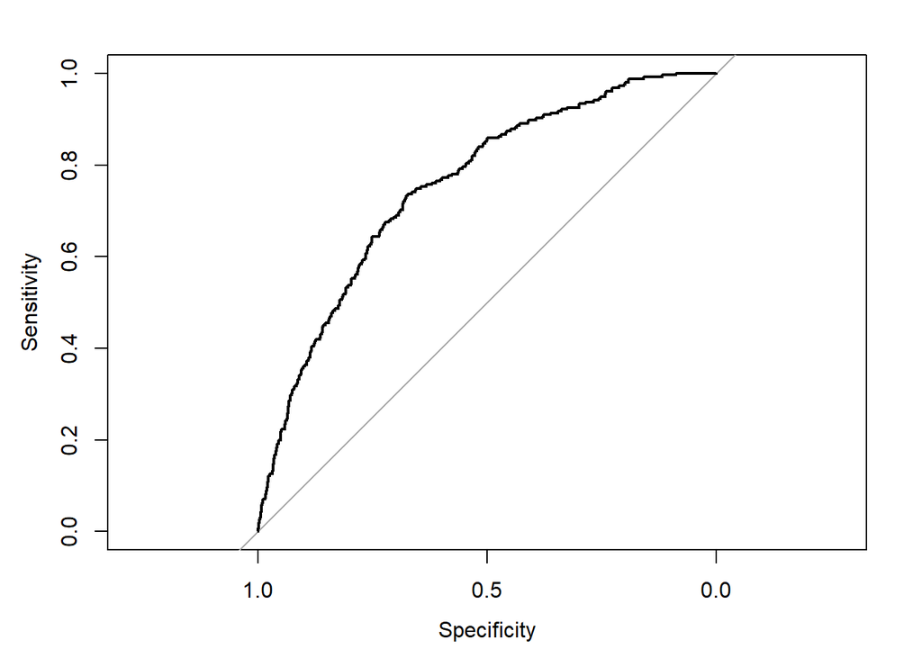

```r
plot(rCurve)
```

## Build Model Using StepAIC

AUC increased to 0.77 and our threshold is now -2.34 using 2nd order interactions. This corresponds to 9% odds of a CHD event, which still seems like a low threshold, which leads me to believe that we are missing some additional information in this model and may have some better predictors.

```
##
## Call:
## glm(formula = step2$formula, family = "binomial", data = step2$model)
##
## Deviance Residuals:
##     Min       1Q   Median       3Q      Max
## -1.4129  -0.4309  -0.2983  -0.1912   2.9510
##
## Coefficients:
##                   Estimate Std. Error z value Pr(>|z|)
## (Intercept)     -1.243e+02  5.341e+01  -2.326 0.020008 *
## age             -9.156e-02  1.069e-01  -0.856 0.391755
## arcus1           1.386e+00  1.619e+00   0.856 0.391951
## behpatA2         9.048e+01  5.754e+01   1.573 0.115829
## behpatB3         1.596e+02  6.291e+01   2.536 0.011210 *
## behpatB4         7.257e+00  1.055e+02   0.069 0.945170
## bmi              4.623e-01  1.706e+00   0.271 0.786428
## chol             4.278e-02  1.184e-02   3.614 0.000301 ***
## dbp              1.055e-01  8.522e-02   1.238 0.215858
## height           1.391e+00  7.600e-01   1.830 0.067243 .
## ncigs            9.335e-02  4.582e-02   2.037 0.041629 *
## sbp              5.669e-03  8.334e-03   0.680 0.496332
## weight          -5.705e-01  2.996e-01  -1.904 0.056905 .
## age:arcus1      -5.745e-02  2.547e-02  -2.256 0.024075 *
## age:dbp          2.071e-03  1.249e-03   1.657 0.097485 .
## arcus1:dbp      -3.434e-02  2.276e-02  -1.509 0.131351
## arcus1:sbp       3.343e-02  1.386e-02   2.412 0.015859 *
## behpatA2:bmi    -1.903e+00  1.125e+00  -1.692 0.090652 .
## behpatB3:bmi    -3.414e+00  1.242e+00  -2.748 0.005994 **
## behpatB4:bmi    -3.957e-01  2.060e+00  -0.192 0.847676
## behpatA2:height -1.333e+00  8.291e-01  -1.607 0.107988
## behpatB3:height -2.300e+00  9.028e-01  -2.548 0.010837 *
## behpatB4:height -2.092e-01  1.504e+00  -0.139 0.889368
## behpatA2:weight  2.900e-01  1.646e-01   1.762 0.078064 .
## behpatB3:weight  4.946e-01  1.799e-01   2.749 0.005983 **
## behpatB4:weight  9.636e-02  2.946e-01   0.327 0.743570
## bmi:dbp         -7.618e-03  2.497e-03  -3.051 0.002284 **
## bmi:height       6.396e-02  4.559e-02   1.403 0.160665
## bmi:ncigs       -2.885e-03  1.827e-03  -1.579 0.114352
## chol:weight     -1.786e-04  6.639e-05  -2.690 0.007137 **
## ---
## Signif. codes:  0 '***' 0.001 '**' 0.01 '*' 0.05 '.' 0.1 ' ' 1
##
## (Dispersion parameter for binomial family taken to be 1)
##
##     Null deviance: 1769.2  on 3139  degrees of freedom
## Residual deviance: 1521.4  on 3110  degrees of freedom
## AIC: 1581.4
##
## Number of Fisher Scoring iterations: 6
```

```
##
## Call:
## roc.formula(formula = dTrim$chd69 ~ predictions2)
##
## Data: predictions2 in 2885 controls (dTrim$chd69 No) < 255 cases (dTrim$chd69 Yes).
## Area under the curve: 0.7759
```

```
##   threshold
## 1 -2.340632
```

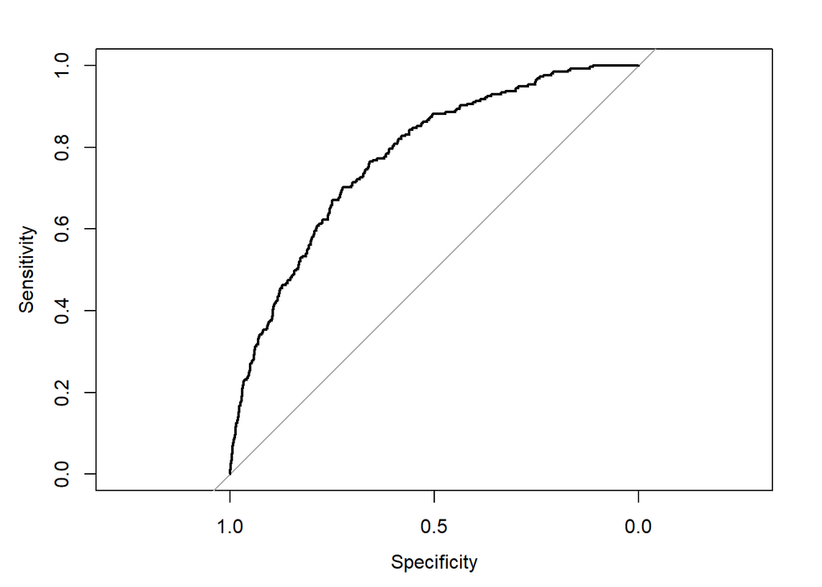

## Model w/ 3rd order Effects

Unfortunately, this was taking too long to run, so I left the code in but commented it out for the sake of time. I suspect that the AUC would increase with the additional interaction effects and that the threshold would also increase based on the 2nd order interaction model.

```r
#logit3 <- glm(chd69~.^3, data = dTrim, family = "binomial")
#step3<- stepAIC(logit3, trace = FALSE)
#bestModel3 = glm(step3$formula, data = step3$model, family="binomial")
#summary(bestModel3)
#predictions3 = predict(bestModel3)
#rCurve3= roc(dTrim$chd69~predictions3)
#rCurve3
#coords(rCurve3, "best", ret ="threshold")
#plot(rCurve3)
```